# Risk Factor Analysis

## Outcome Variable

**Outcome Variable:** whz

## Predictor Variables

**Intervention Variable:** nrooms

**Adjustment Set:**

- arm
- sex
- W_mage
- meducyrs
- feducyrs
- hhwealth_quart
- hfoodsec
- W_mhtcm
- W_mwtkg
- W_mbmi
- W_nchldlt5
- W_parity
- impfloor
- impsan
- safeh20
- delta_W_mage
- delta_meducyrs
- delta_feducyrs
- delta_hhwealth_quart
- delta_hfoodsec
- delta_W_mhtcm
- delta_W_mwtkg
- delta_W_mbmi
- delta_W_nchldlt5
- delta_W_parity
- delta_impfloor
- delta_impsan
- delta_safeh20

## Stratifying Variables

The analysis was stratified on these variable(s):

- agecat
- studyid
- country

## Data Summary

| agecat | studyid | country | nrooms | n_cell | n |
| --- | --- | --- | --- | --- | --- |
| Birth | ki0047075b-MAL-ED | BANGLADESH | 4+ | 12 | 201 |
| Birth | ki0047075b-MAL-ED | BANGLADESH | 1 | 121 | 201 |
| Birth | ki0047075b-MAL-ED | BANGLADESH | 2 | 43 | 201 |
| Birth | ki0047075b-MAL-ED | BANGLADESH | 3 | 25 | 201 |
| Birth | ki0047075b-MAL-ED | BRAZIL | 4+ | 29 | 57 |
| Birth | ki0047075b-MAL-ED | BRAZIL | 1 | 0 | 57 |
| Birth | ki0047075b-MAL-ED | BRAZIL | 2 | 10 | 57 |
| Birth | ki0047075b-MAL-ED | BRAZIL | 3 | 18 | 57 |
| Birth | ki0047075b-MAL-ED | INDIA | 4+ | 2 | 39 |
| Birth | ki0047075b-MAL-ED | INDIA | 1 | 17 | 39 |
| Birth | ki0047075b-MAL-ED | INDIA | 2 | 16 | 39 |
| Birth | ki0047075b-MAL-ED | INDIA | 3 | 4 | 39 |
| Birth | ki0047075b-MAL-ED | NEPAL | 4+ | 15 | 25 |
| Birth | ki0047075b-MAL-ED | NEPAL | 1 | 6 | 25 |
| Birth | ki0047075b-MAL-ED | NEPAL | 2 | 2 | 25 |
| Birth | ki0047075b-MAL-ED | NEPAL | 3 | 2 | 25 |
| Birth | ki0047075b-MAL-ED | PERU | 4+ | 103 | 210 |
| Birth | ki0047075b-MAL-ED | PERU | 1 | 13 | 210 |
| Birth | ki0047075b-MAL-ED | PERU | 2 | 45 | 210 |
| Birth | ki0047075b-MAL-ED | PERU | 3 | 49 | 210 |
| Birth | ki0047075b-MAL-ED | SOUTH AFRICA | 4+ | 66 | 95 |
| Birth | ki0047075b-MAL-ED | SOUTH AFRICA | 1 | 5 | 95 |
| Birth | ki0047075b-MAL-ED | SOUTH AFRICA | 2 | 12 | 95 |
| Birth | ki0047075b-MAL-ED | SOUTH AFRICA | 3 | 12 | 95 |
| Birth | ki0047075b-MAL-ED | TANZANIA, UNITED REPUBLIC OF | 4+ | 45 | 112 |
| Birth | ki0047075b-MAL-ED | TANZANIA, UNITED REPUBLIC OF | 1 | 9 | 112 |
| Birth | ki0047075b-MAL-ED | TANZANIA, UNITED REPUBLIC OF | 2 | 28 | 112 |
| Birth | ki0047075b-MAL-ED | TANZANIA, UNITED REPUBLIC OF | 3 | 30 | 112 |
| Birth | ki1000108-CMC-V-BCS-2002 | INDIA | 4+ | 5 | 86 |
| Birth | ki1000108-CMC-V-BCS-2002 | INDIA | 1 | 35 | 86 |

[output cut: 162 more lines]

The following strata were considered:

- agecat: 24 months, studyid: ki0047075b-MAL-ED, country: BANGLADESH
- agecat: 24 months, studyid: ki0047075b-MAL-ED, country: BRAZIL
- agecat: 24 months, studyid: ki0047075b-MAL-ED, country: INDIA
- agecat: 24 months, studyid: ki0047075b-MAL-ED, country: NEPAL
- agecat: 24 months, studyid: ki0047075b-MAL-ED, country: PERU
- agecat: 24 months, studyid: ki0047075b-MAL-ED, country: SOUTH AFRICA
- agecat: 24 months, studyid: ki0047075b-MAL-ED, country: TANZANIA, UNITED REPUBLIC OF
- agecat: 24 months, studyid: ki1000108-CMC-V-BCS-2002, country: INDIA
- agecat: 24 months, studyid: ki1000108-IRC, country: INDIA
- agecat: 24 months, studyid: ki1017093b-PROVIDE, country: BANGLADESH
- agecat: 24 months, studyid: ki1017093c-NIH-Crypto, country: BANGLADESH
- agecat: 24 months, studyid: ki1113344-GMS-Nepal, country: NEPAL
- agecat: 24 months, studyid: ki1114097-CONTENT, country: PERU
- agecat: 24 months, studyid: ki1135781-COHORTS, country: INDIA
- agecat: 24 months, studyid: kiGH5241-JiVitA-3, country: BANGLADESH
- agecat: 24 months, studyid: kiGH5241-JiVitA-4, country: BANGLADESH
- agecat: 6 months, studyid: ki0047075b-MAL-ED, country: BANGLADESH
- agecat: 6 months, studyid: ki0047075b-MAL-ED, country: BRAZIL
- agecat: 6 months, studyid: ki0047075b-MAL-ED, country: INDIA
- agecat: 6 months, studyid: ki0047075b-MAL-ED, country: NEPAL
- agecat: 6 months, studyid: ki0047075b-MAL-ED, country: PERU
- agecat: 6 months, studyid: ki0047075b-MAL-ED, country: SOUTH AFRICA
- agecat: 6 months, studyid: ki0047075b-MAL-ED, country: TANZANIA, UNITED REPUBLIC OF
- agecat: 6 months, studyid: ki1000108-CMC-V-BCS-2002, country: INDIA
- agecat: 6 months, studyid: ki1000108-IRC, country: INDIA
- agecat: 6 months, studyid: ki1017093b-PROVIDE, country: BANGLADESH
- agecat: 6 months, studyid: ki1017093c-NIH-Crypto, country: BANGLADESH
- agecat: 6 months, studyid: ki1113344-GMS-Nepal, country: NEPAL
- agecat: 6 months, studyid: ki1114097-CONTENT, country: PERU
- agecat: 6 months, studyid: ki1135781-COHORTS, country: INDIA
- agecat: 6 months, studyid: kiGH5241-JiVitA-3, country: BANGLADESH
- agecat: 6 months, studyid: kiGH5241-JiVitA-4, country: BANGLADESH
- agecat: Birth, studyid: ki0047075b-MAL-ED, country: BANGLADESH
- agecat: Birth, studyid: ki0047075b-MAL-ED, country: BRAZIL
- agecat: Birth, studyid: ki0047075b-MAL-ED, country: INDIA
- agecat: Birth, studyid: ki0047075b-MAL-ED, country: NEPAL
- agecat: Birth, studyid: ki0047075b-MAL-ED, country: PERU
- agecat: Birth, studyid: ki0047075b-MAL-ED, country: SOUTH AFRICA
- agecat: Birth, studyid: ki0047075b-MAL-ED, country: TANZANIA, UNITED REPUBLIC OF
- agecat: Birth, studyid: ki1000108-CMC-V-BCS-2002, country: INDIA
- agecat: Birth, studyid: ki1000108-IRC, country: INDIA
- agecat: Birth, studyid: ki1017093b-PROVIDE, country: BANGLADESH
- agecat: Birth, studyid: ki1017093c-NIH-Crypto, country: BANGLADESH
- agecat: Birth, studyid: ki1113344-GMS-Nepal, country: NEPAL
- agecat: Birth, studyid: ki1114097-CONTENT, country: PERU
- agecat: Birth, studyid: ki1135781-COHORTS, country: INDIA
- agecat: Birth, studyid: kiGH5241-JiVitA-3, country: BANGLADESH
- agecat: Birth, studyid: kiGH5241-JiVitA-4, country: BANGLADESH

### Dropped Strata

Some strata were dropped due to rare outcomes:

- agecat: Birth, studyid: ki0047075b-MAL-ED, country: BRAZIL
- agecat: Birth, studyid: ki0047075b-MAL-ED, country: INDIA
- agecat: Birth, studyid: ki0047075b-MAL-ED, country: NEPAL
- agecat: Birth, studyid: ki1114097-CONTENT, country: PERU
- agecat: 6 months, studyid: ki0047075b-MAL-ED, country: BRAZIL
- agecat: 24 months, studyid: ki0047075b-MAL-ED, country: BRAZIL

## Methods Detail

We’re interested in the causal parameters $E[Y_a]$ for all values of $a \in \mathcal{A}$. These parameters represent the mean outcome if, possibly contrary to fact, we intervened to set all units to have $A=a$. Under the randomization and positivity assumptions, these are identified by the statistical parameters $\psi_a=E_W[E_{Y|A,W}(Y|A=a,W)]$. In addition, we’re interested in the mean of $Y$, $E[Y]$ under no intervention (the observed mean). We will estimate these parameters by using SuperLearner to fit the relevant likelihood factors – $E_{Y|A,W}(Y|A=a,W)$ and $p(A=a|W)$, and then updating our likelihood fit using a joint TMLE.

For unadjusted analyses ($W=\{\}$), initial likelihoods were estimated using Lrnr_glm to estimate the simple $E(Y|A)$ and Lrnr_mean to estimate $p(A)$. For adjusted analyses, a small library containing Lrnr_glmnet, Lrnr_xgboost, and Lrnr_mean was used.

Having estimated these parameters, we will then use the delta method to estimate relative risks and attributable risks relative to a prespecified baseline level of $A$.

# Results Detail

## Results Plots

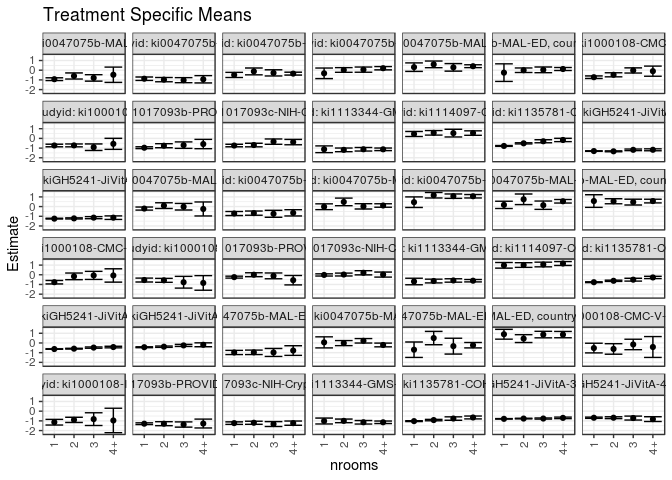

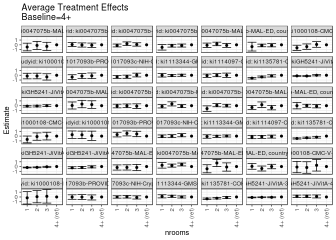

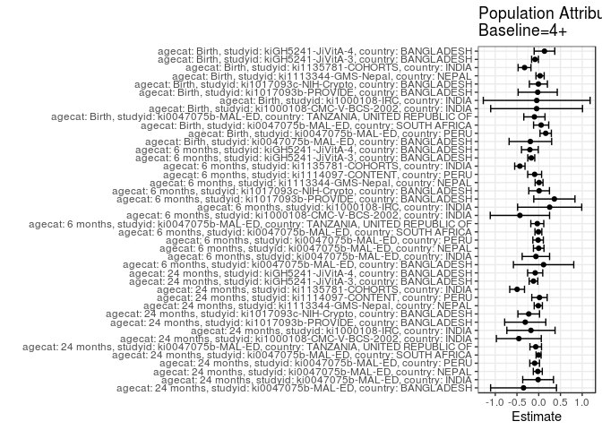

## Results Table

### Parameter: TSM

| agecat | studyid | country | intervention_level | baseline_level | estimate | ci_lower | ci_upper |
| --- | --- | --- | --- | --- | --- | --- | --- |
| Birth | ki0047075b-MAL-ED | BANGLADESH | 4+ | NA | -0.7810734 | -1.2764608 | -0.2856861 |
| Birth | ki0047075b-MAL-ED | BANGLADESH | 1 | NA | -0.9811578 | -1.1977163 | -0.7645994 |
| Birth | ki0047075b-MAL-ED | BANGLADESH | 2 | NA | -0.9674891 | -1.1976737 | -0.7373046 |
| Birth | ki0047075b-MAL-ED | BANGLADESH | 3 | NA | -0.9766083 | -1.3861998 | -0.5670168 |
| Birth | ki0047075b-MAL-ED | PERU | 4+ | NA | -0.2074578 | -0.3994923 | -0.0154233 |
| Birth | ki0047075b-MAL-ED | PERU | 1 | NA | 0.0614630 | -0.5073924 | 0.6303183 |
| Birth | ki0047075b-MAL-ED | PERU | 2 | NA | -0.0128312 | -0.2731589 | 0.2474965 |
| Birth | ki0047075b-MAL-ED | PERU | 3 | NA | 0.2244393 | -0.0055106 | 0.4543891 |
| Birth | ki0047075b-MAL-ED | SOUTH AFRICA | 4+ | NA | -0.2287879 | -0.5065288 | 0.0489530 |
| Birth | ki0047075b-MAL-ED | SOUTH AFRICA | 1 | NA | -0.6960000 | -1.4913352 | 0.0993352 |
| Birth | ki0047075b-MAL-ED | SOUTH AFRICA | 2 | NA | 0.5066667 | -0.1807332 | 1.1940665 |
| Birth | ki0047075b-MAL-ED | SOUTH AFRICA | 3 | NA | -0.3275000 | -1.1444022 | 0.4894022 |
| Birth | ki0047075b-MAL-ED | TANZANIA, UNITED REPUBLIC OF | 4+ | NA | 0.8631111 | 0.5363093 | 1.1899130 |
| Birth | ki0047075b-MAL-ED | TANZANIA, UNITED REPUBLIC OF | 1 | NA | 0.9000000 | 0.3934379 | 1.4065621 |
| Birth | ki0047075b-MAL-ED | TANZANIA, UNITED REPUBLIC OF | 2 | NA | 0.4500000 | 0.0450331 | 0.8549669 |
| Birth | ki0047075b-MAL-ED | TANZANIA, UNITED REPUBLIC OF | 3 | NA | 0.8666667 | 0.5289823 | 1.2043510 |
| Birth | ki1000108-CMC-V-BCS-2002 | INDIA | 4+ | NA | -0.4160000 | -1.4929959 | 0.6609959 |
| Birth | ki1000108-CMC-V-BCS-2002 | INDIA | 1 | NA | -0.5244286 | -1.0232807 | -0.0255765 |
| Birth | ki1000108-CMC-V-BCS-2002 | INDIA | 2 | NA | -0.6155556 | -1.1573805 | -0.0737306 |
| Birth | ki1000108-CMC-V-BCS-2002 | INDIA | 3 | NA | -0.1536842 | -0.6942308 | 0.3868624 |
| Birth | ki1000108-IRC | INDIA | 4+ | NA | -0.9590592 | -2.2191474 | 0.3010290 |
| Birth | ki1000108-IRC | INDIA | 1 | NA | -1.1383443 | -1.4293331 | -0.8473555 |
| Birth | ki1000108-IRC | INDIA | 2 | NA | -0.8970218 | -1.1653611 | -0.6286824 |
| Birth | ki1000108-IRC | INDIA | 3 | NA | -0.8217007 | -1.4771433 | -0.1662582 |
| Birth | ki1017093b-PROVIDE | BANGLADESH | 4+ | NA | -1.2750287 | -1.7335998 | -0.8164576 |
| Birth | ki1017093b-PROVIDE | BANGLADESH | 1 | NA | -1.2915679 | -1.3805679 | -1.2025679 |
| Birth | ki1017093b-PROVIDE | BANGLADESH | 2 | NA | -1.2917444 | -1.4955781 | -1.0879106 |
| Birth | ki1017093b-PROVIDE | BANGLADESH | 3 | NA | -1.3757520 | -1.6463653 | -1.1051386 |
| Birth | ki1017093c-NIH-Crypto | BANGLADESH | 4+ | NA | -1.2367239 | -1.4536542 | -1.0197937 |
| Birth | ki1017093c-NIH-Crypto | BANGLADESH | 1 | NA | -1.2333980 | -1.3629960 | -1.1037999 |

[output cut: 138 more lines]

### Parameter: E(Y)

| agecat | studyid | country | intervention_level | baseline_level | estimate | ci_lower | ci_upper |
| --- | --- | --- | --- | --- | --- | --- | --- |
| Birth | ki0047075b-MAL-ED | BANGLADESH | NA | NA | -0.9728358 | -1.1217009 | -0.8239707 |
| Birth | ki0047075b-MAL-ED | PERU | NA | NA | -0.0468095 | -0.1738806 | 0.0802616 |
| Birth | ki0047075b-MAL-ED | SOUTH AFRICA | NA | NA | -0.1729474 | -0.4186222 | 0.0727275 |
| Birth | ki0047075b-MAL-ED | TANZANIA, UNITED REPUBLIC OF | NA | NA | 0.7637500 | 0.5676177 | 0.9598823 |
| Birth | ki1000108-CMC-V-BCS-2002 | INDIA | NA | NA | -0.4648256 | -0.7643210 | -0.1653302 |
| Birth | ki1000108-IRC | INDIA | NA | NA | -1.0053372 | -1.1922119 | -0.8184626 |
| Birth | ki1017093b-PROVIDE | BANGLADESH | NA | NA | -1.2984586 | -1.3752758 | -1.2216415 |
| Birth | ki1017093c-NIH-Crypto | BANGLADESH | NA | NA | -1.2441513 | -1.3281130 | -1.1601897 |
| Birth | ki1113344-GMS-Nepal | NEPAL | NA | NA | -1.1164431 | -1.2040134 | -1.0288728 |
| Birth | ki1135781-COHORTS | INDIA | NA | NA | -0.9778087 | -1.0126530 | -0.9429644 |
| Birth | kiGH5241-JiVitA-3 | BANGLADESH | NA | NA | -0.7776536 | -0.7966730 | -0.7586341 |
| Birth | kiGH5241-JiVitA-4 | BANGLADESH | NA | NA | -0.6882498 | -0.7406539 | -0.6358456 |
| 6 months | ki0047075b-MAL-ED | BANGLADESH | NA | NA | -0.1333333 | -0.2623761 | -0.0042906 |
| 6 months | ki0047075b-MAL-ED | INDIA | NA | NA | -0.7102872 | -0.8371659 | -0.5834085 |
| 6 months | ki0047075b-MAL-ED | NEPAL | NA | NA | 0.1104308 | -0.0208643 | 0.2417259 |
| 6 months | ki0047075b-MAL-ED | PERU | NA | NA | 1.0512099 | 0.9285617 | 1.1738581 |
| 6 months | ki0047075b-MAL-ED | SOUTH AFRICA | NA | NA | 0.5404351 | 0.3867005 | 0.6941696 |
| 6 months | ki0047075b-MAL-ED | TANZANIA, UNITED REPUBLIC OF | NA | NA | 0.5362213 | 0.4049390 | 0.6675036 |
| 6 months | ki1000108-CMC-V-BCS-2002 | INDIA | NA | NA | -0.5026766 | -0.6536848 | -0.3516685 |
| 6 months | ki1000108-IRC | INDIA | NA | NA | -0.5900821 | -0.7252457 | -0.4549185 |
| 6 months | ki1017093b-PROVIDE | BANGLADESH | NA | NA | -0.1990907 | -0.2817968 | -0.1163845 |
| 6 months | ki1017093c-NIH-Crypto | BANGLADESH | NA | NA | 0.0297622 | -0.0491685 | 0.1086930 |
| 6 months | ki1113344-GMS-Nepal | NEPAL | NA | NA | -0.6038416 | -0.6899448 | -0.5177384 |
| 6 months | ki1114097-CONTENT | PERU | NA | NA | 1.0684318 | 0.9515274 | 1.1853362 |
| 6 months | ki1135781-COHORTS | INDIA | NA | NA | -0.7088012 | -0.7411274 | -0.6764750 |
| 6 months | kiGH5241-JiVitA-3 | BANGLADESH | NA | NA | -0.5930302 | -0.6125738 | -0.5734865 |
| 6 months | kiGH5241-JiVitA-4 | BANGLADESH | NA | NA | -0.3901595 | -0.4274150 | -0.3529041 |
| 24 months | ki0047075b-MAL-ED | BANGLADESH | NA | NA | -0.8192925 | -0.9412667 | -0.6973182 |
| 24 months | ki0047075b-MAL-ED | INDIA | NA | NA | -0.9516520 | -1.0670654 | -0.8362385 |
| 24 months | ki0047075b-MAL-ED | NEPAL | NA | NA | -0.3749123 | -0.4886073 | -0.2612173 |
| 24 months | ki0047075b-MAL-ED | PERU | NA | NA | 0.1111982 | -0.0118399 | 0.2342362 |
| 24 months | ki0047075b-MAL-ED | SOUTH AFRICA | NA | NA | 0.4090301 | 0.2879441 | 0.5301161 |
| 24 months | ki0047075b-MAL-ED | TANZANIA, UNITED REPUBLIC OF | NA | NA | 0.0547975 | -0.0703378 | 0.1799328 |
| 24 months | ki1000108-CMC-V-BCS-2002 | INDIA | NA | NA | -0.5571505 | -0.6585247 | -0.4557763 |
| 24 months | ki1000108-IRC | INDIA | NA | NA | -0.7416790 | -0.8323562 | -0.6510017 |
| 24 months | ki1017093b-PROVIDE | BANGLADESH | NA | NA | -0.8928670 | -0.9755153 | -0.8102187 |
| 24 months | ki1017093c-NIH-Crypto | BANGLADESH | NA | NA | -0.6103502 | -0.7050157 | -0.5156847 |
| 24 months | ki1113344-GMS-Nepal | NEPAL | NA | NA | -1.1363107 | -1.2252817 | -1.0473398 |
| 24 months | ki1114097-CONTENT | PERU | NA | NA | 0.5668293 | 0.4302437 | 0.7034148 |
| 24 months | ki1135781-COHORTS | INDIA | NA | NA | -0.6612799 | -0.6944511 | -0.6281088 |
| 24 months | kiGH5241-JiVitA-3 | BANGLADESH | NA | NA | -1.2967966 | -1.3200807 | -1.2735126 |
| 24 months | kiGH5241-JiVitA-4 | BANGLADESH | NA | NA | -1.2231776 | -1.2550332 | -1.1913220 |

### Parameter: ATE

| agecat | studyid | country | intervention_level | baseline_level | estimate | ci_lower | ci_upper |
| --- | --- | --- | --- | --- | --- | --- | --- |
| Birth | ki0047075b-MAL-ED | BANGLADESH | 4+ | 4+ | 0.0000000 | 0.0000000 | 0.0000000 |
| Birth | ki0047075b-MAL-ED | BANGLADESH | 1 | 4+ | -0.2000844 | -0.7411366 | 0.3409678 |
| Birth | ki0047075b-MAL-ED | BANGLADESH | 2 | 4+ | -0.1864157 | -0.7326915 | 0.3598601 |
| Birth | ki0047075b-MAL-ED | BANGLADESH | 3 | 4+ | -0.1955348 | -0.8386848 | 0.4476151 |
| Birth | ki0047075b-MAL-ED | PERU | 4+ | 4+ | 0.0000000 | 0.0000000 | 0.0000000 |
| Birth | ki0047075b-MAL-ED | PERU | 1 | 4+ | 0.2689208 | -0.3318063 | 0.8696478 |
| Birth | ki0047075b-MAL-ED | PERU | 2 | 4+ | 0.1946266 | -0.1275157 | 0.5167689 |
| Birth | ki0047075b-MAL-ED | PERU | 3 | 4+ | 0.4318971 | 0.1308458 | 0.7329484 |
| Birth | ki0047075b-MAL-ED | SOUTH AFRICA | 4+ | 4+ | 0.0000000 | 0.0000000 | 0.0000000 |
| Birth | ki0047075b-MAL-ED | SOUTH AFRICA | 1 | 4+ | -0.4672121 | -1.3096480 | 0.3752237 |
| Birth | ki0047075b-MAL-ED | SOUTH AFRICA | 2 | 4+ | 0.7354545 | -0.0059351 | 1.4768442 |
| Birth | ki0047075b-MAL-ED | SOUTH AFRICA | 3 | 4+ | -0.0987121 | -0.9615385 | 0.7641142 |
| Birth | ki0047075b-MAL-ED | TANZANIA, UNITED REPUBLIC OF | 4+ | 4+ | 0.0000000 | 0.0000000 | 0.0000000 |
| Birth | ki0047075b-MAL-ED | TANZANIA, UNITED REPUBLIC OF | 1 | 4+ | 0.0368889 | -0.5659416 | 0.6397194 |
| Birth | ki0047075b-MAL-ED | TANZANIA, UNITED REPUBLIC OF | 2 | 4+ | -0.4131111 | -0.9334933 | 0.1072711 |
| Birth | ki0047075b-MAL-ED | TANZANIA, UNITED REPUBLIC OF | 3 | 4+ | 0.0035556 | -0.4663701 | 0.4734813 |
| Birth | ki1000108-CMC-V-BCS-2002 | INDIA | 4+ | 4+ | 0.0000000 | 0.0000000 | 0.0000000 |
| Birth | ki1000108-CMC-V-BCS-2002 | INDIA | 1 | 4+ | -0.1084286 | -1.2953462 | 1.0784891 |
| Birth | ki1000108-CMC-V-BCS-2002 | INDIA | 2 | 4+ | -0.1995556 | -1.4051651 | 1.0060540 |
| Birth | ki1000108-CMC-V-BCS-2002 | INDIA | 3 | 4+ | 0.2623158 | -0.9427198 | 1.4673514 |
| Birth | ki1000108-IRC | INDIA | 4+ | 4+ | 0.0000000 | 0.0000000 | 0.0000000 |
| Birth | ki1000108-IRC | INDIA | 1 | 4+ | -0.1792851 | -1.4728952 | 1.1143250 |
| Birth | ki1000108-IRC | INDIA | 2 | 4+ | 0.0620374 | -1.2269665 | 1.3510414 |
| Birth | ki1000108-IRC | INDIA | 3 | 4+ | 0.1373585 | -1.2830005 | 1.5577174 |
| Birth | ki1017093b-PROVIDE | BANGLADESH | 4+ | 4+ | 0.0000000 | 0.0000000 | 0.0000000 |
| Birth | ki1017093b-PROVIDE | BANGLADESH | 1 | 4+ | -0.0165392 | -0.4834237 | 0.4503453 |
| Birth | ki1017093b-PROVIDE | BANGLADESH | 2 | 4+ | -0.0167157 | -0.5183142 | 0.4848829 |
| Birth | ki1017093b-PROVIDE | BANGLADESH | 3 | 4+ | -0.1007233 | -0.6326840 | 0.4312375 |
| Birth | ki1017093c-NIH-Crypto | BANGLADESH | 4+ | 4+ | 0.0000000 | 0.0000000 | 0.0000000 |
| Birth | ki1017093c-NIH-Crypto | BANGLADESH | 1 | 4+ | 0.0033259 | -0.2490366 | 0.2556885 |

[output cut: 138 more lines]

### Parameter: PAR

| agecat | studyid | country | intervention_level | baseline_level | estimate | ci_lower | ci_upper |
| --- | --- | --- | --- | --- | --- | --- | --- |
| Birth | ki0047075b-MAL-ED | BANGLADESH | 4+ | NA | -0.1917624 | -0.6810401 | 0.2975154 |
| Birth | ki0047075b-MAL-ED | PERU | 4+ | NA | 0.1606483 | 0.0302605 | 0.2910361 |
| Birth | ki0047075b-MAL-ED | SOUTH AFRICA | 4+ | NA | 0.0558405 | -0.1182633 | 0.2299443 |
| Birth | ki0047075b-MAL-ED | TANZANIA, UNITED REPUBLIC OF | 4+ | NA | -0.0993611 | -0.3431773 | 0.1444551 |
| Birth | ki1000108-CMC-V-BCS-2002 | INDIA | 4+ | NA | -0.0488256 | -1.1046396 | 1.0069884 |
| Birth | ki1000108-IRC | INDIA | 4+ | NA | -0.0462780 | -1.2748380 | 1.1822820 |
| Birth | ki1017093b-PROVIDE | BANGLADESH | 4+ | NA | -0.0234299 | -0.4735124 | 0.4266525 |
| Birth | ki1017093c-NIH-Crypto | BANGLADESH | 4+ | NA | -0.0074274 | -0.2145798 | 0.1997250 |
| Birth | ki1113344-GMS-Nepal | NEPAL | 4+ | NA | 0.0312207 | -0.0629905 | 0.1254320 |
| Birth | ki1135781-COHORTS | INDIA | 4+ | NA | -0.3263397 | -0.4739924 | -0.1786870 |
| Birth | kiGH5241-JiVitA-3 | BANGLADESH | 4+ | NA | -0.0850203 | -0.1633514 | -0.0066891 |
| Birth | kiGH5241-JiVitA-4 | BANGLADESH | 4+ | NA | 0.1321768 | -0.1051163 | 0.3694700 |
| 6 months | ki0047075b-MAL-ED | BANGLADESH | 4+ | NA | 0.1121853 | -0.5818208 | 0.8061913 |
| 6 months | ki0047075b-MAL-ED | INDIA | 4+ | NA | -0.0651526 | -0.3806417 | 0.2503366 |
| 6 months | ki0047075b-MAL-ED | NEPAL | 4+ | NA | -0.0004359 | -0.1215263 | 0.1206544 |
| 6 months | ki0047075b-MAL-ED | PERU | 4+ | NA | -0.0139781 | -0.1346603 | 0.1067042 |
| 6 months | ki0047075b-MAL-ED | SOUTH AFRICA | 4+ | NA | -0.0074103 | -0.0864585 | 0.0716380 |
| 6 months | ki0047075b-MAL-ED | TANZANIA, UNITED REPUBLIC OF | 4+ | NA | -0.0326116 | -0.1818821 | 0.1166589 |
| 6 months | ki1000108-CMC-V-BCS-2002 | INDIA | 4+ | NA | -0.4325291 | -1.1149245 | 0.2498663 |
| 6 months | ki1000108-IRC | INDIA | 4+ | NA | 0.2518724 | -0.4857353 | 0.9894800 |
| 6 months | ki1017093b-PROVIDE | BANGLADESH | 4+ | NA | 0.3598918 | -0.1138556 | 0.8336391 |
| 6 months | ki1017093c-NIH-Crypto | BANGLADESH | 4+ | NA | 0.0094994 | -0.2283709 | 0.2473697 |
| 6 months | ki1113344-GMS-Nepal | NEPAL | 4+ | NA | 0.0077991 | -0.0825638 | 0.0981620 |
| 6 months | ki1114097-CONTENT | PERU | 4+ | NA | -0.0934812 | -0.2534601 | 0.0664977 |
| 6 months | ki1135781-COHORTS | INDIA | 4+ | NA | -0.4339897 | -0.5528702 | -0.3151091 |
| 6 months | kiGH5241-JiVitA-3 | BANGLADESH | 4+ | NA | -0.1711434 | -0.2510533 | -0.0912336 |
| 6 months | kiGH5241-JiVitA-4 | BANGLADESH | 4+ | NA | -0.2033216 | -0.3961673 | -0.0104760 |
| 24 months | ki0047075b-MAL-ED | BANGLADESH | 4+ | NA | -0.3491390 | -1.1067462 | 0.4084683 |
| 24 months | ki0047075b-MAL-ED | INDIA | 4+ | NA | -0.0140987 | -0.3679412 | 0.3397439 |
| 24 months | ki0047075b-MAL-ED | NEPAL | 4+ | NA | -0.0211009 | -0.1243002 | 0.0820985 |
| 24 months | ki0047075b-MAL-ED | PERU | 4+ | NA | -0.0935136 | -0.2050125 | 0.0179853 |
| 24 months | ki0047075b-MAL-ED | SOUTH AFRICA | 4+ | NA | -0.0029957 | -0.0609816 | 0.0549902 |
| 24 months | ki0047075b-MAL-ED | TANZANIA, UNITED REPUBLIC OF | 4+ | NA | -0.0689440 | -0.2018628 | 0.0639748 |
| 24 months | ki1000108-CMC-V-BCS-2002 | INDIA | 4+ | NA | -0.4573619 | -0.9736491 | 0.0589253 |
| 24 months | ki1000108-IRC | INDIA | 4+ | NA | -0.1785406 | -0.7332285 | 0.3761473 |
| 24 months | ki1017093b-PROVIDE | BANGLADESH | 4+ | NA | -0.3103156 | -0.7834221 | 0.1627908 |
| 24 months | ki1017093c-NIH-Crypto | BANGLADESH | 4+ | NA | -0.2299471 | -0.4788854 | 0.0189911 |
| 24 months | ki1113344-GMS-Nepal | NEPAL | 4+ | NA | -0.0097774 | -0.1038159 | 0.0842611 |
| 24 months | ki1114097-CONTENT | PERU | 4+ | NA | 0.0173584 | -0.1596701 | 0.1943869 |
| 24 months | ki1135781-COHORTS | INDIA | 4+ | NA | -0.4968436 | -0.6666750 | -0.3270121 |
| 24 months | kiGH5241-JiVitA-3 | BANGLADESH | 4+ | NA | -0.1209624 | -0.2199825 | -0.0219423 |
| 24 months | kiGH5241-JiVitA-4 | BANGLADESH | 4+ | NA | -0.0814622 | -0.2552191 | 0.0922948 |